# 03 Reproducible reporting

# Objective

Let’s analyze some randomly generated gift pipeline data. Suppose we have a set of proposals at different levels expected to close in 2019 or 2020. Can we make some projections on how much can realistically be raised?

# Data

Proposals can be in 1 of 3 different stages. Anticipated proposals are expected to be asked soon, submitted proposals have been presented to a prospective donor, and verbal proposals have been agreed to verbally but the signed documentation has not yet been returned. There are also two different dollar projections: ask amounts are presented to the prospective donor in the proposal, while anticipated amounts are what they are expected to agree to.

# FY19 and FY20 Proposal Pipeline

Here is the amount in the pipeline by proposal status and close date:

| Close FY | FY Anticipated Total | Anticipated Verbal | FY Ask Total | Anticipated | Submitted | Verbal |
| --- | --- | --- | --- | --- | --- | --- |
| 2019 | $95.9M | $1.0M | $124.4M | $77.4M | $45.7M | $1.4M |
| 2020 | $82.5M | $0.2M | $108.1M | $105.4M | $2.4M | $0.2M |

# Some napkin math

Assume the yearly goal is $50.0M and that all verbals close at the anticipated level. Given the pipeline data, raising an additional $50.0M - $1.0M = $49.0M in FY19 requires 39.8% of total anticipated/submitted asked dollars to close, and raising $49.8M in FY20 requires 46.1% of total anticipated/submitted asked dollars to close.

Additionally, I consider any anticipated proposal with a close date of 2020-08-31 (the last day of the campaign) to be a placeholder while the prospect is qualified. I’ll discount placeholders to 50% of their dollar value for projection purposes.

| Close FY | FY Anticipated | FY Anticipated Placeholder | FY Ask | FY Ask Placeholder | Anticipated | Submitted | Verbal |
| --- | --- | --- | --- | --- | --- | --- | --- |
| 2020 | $51.3M | $31.2M | $71.8M | $36.3M | $105.4M | $2.4M | $0.2M |

# Pipeline Simulation

To determine how likely various fundraising outcomes may be, I’ll run a Monte Carlo simulation for each fiscal year. I’ve seen various industry standards suggesting major gift asked dollars close between a 16% (1/6) to 66% (2/3) rate depending on proposal progress and a prospect’s placement in the prospect lifecycle. We can also use gift officer generated probability estimates with the anticipated amounts to provide a second set of possible outcomes.

Assuming $p =$ 0.25 as the baseline close rate and discounting placeholder proposals to 50% of their face amount yields the following simulations.

|  | n | StDev | min | median | mean | max |
| --- | --- | --- | --- | --- | --- | --- |
| FY19 Asks | 2500 | $9.2M | $9.0M | $29.7M | $31.0M | $63.2M |
| FY20 Asks | 2500 | $8.2M | $6.2M | $21.1M | $22.7M | $49.2M |
| FY19 Anticipated | 2500 | $7.3M | $34.3M | $65.9M | $65.3M | $84.3M |
| FY20 Anticipated | 2500 | $5.9M | $22.8M | $47.7M | $46.4M | $59.5M |

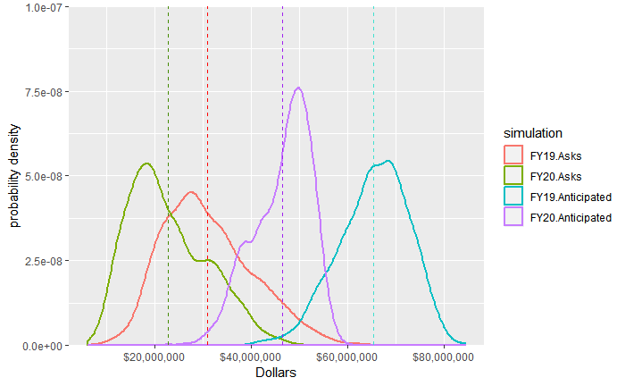

Simulations based on anticipated amounts and anticipated close probabilities are significantly more optimistic than those based on ask amounts and standard industry close probabilities. On average, 1 of the 4 simulations yields results above the $50.0M yearly goal.

# Expected Range of FY19 Outcomes

Consider the FY19 Asks model as the more conservative FY19 projection. Dividing the expected giving ranges into quantiles:

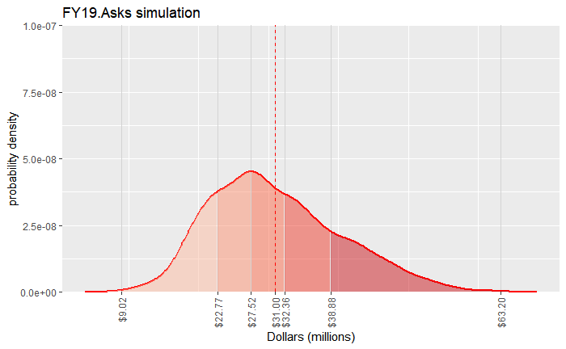

60% of the simulated FY19 outcomes were between $22.8M and $38.9M and the average outcome was $31.0M, which is less than the $50.0M goal.